# Social Network Analysis

Nisha_Antony

Sander_MartinsGoncalves

27/01/2021

# 1. Drawing a network using R

You are provided with a dataset (friendship011.csv), which contains the undirected network for friendship among a group of students. You were also given a dataset with attributes for each student. This includes: - gender (1=female, 0=male), - their grade (going from 0, the lowest to 10, the highest) and - their top music preference (1=Rock Music, 2=Electronic Dance Music, 3=Pop Music, 4=Latin, 5=R&B)

Checking if the order of the file is consistent

```r
sum(rownames(profile_attribute)!=colnames(frienship))
```

```
## [1] 0
```

zero means that there is no different value regarding row/column. Good to go!

## 1.1. Draw the network using the Fruchterman-Reingold layout.

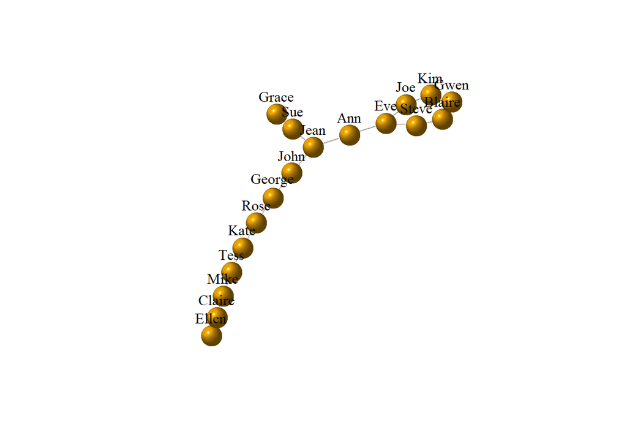

## 1.2. Next draw the network again using the Fruchterman-Reingold layout but now with attributes gender, age and top music preference.

```
## IGRAPH c78a5da UN-- 18 18 --
## + attr: name (v/c), Gender (v/n), Grade (v/n), Music (v/n)
## + edges from c78a5da (vertex names):
##  [1] Kate  --Rose   Kate  --Tess   Rose  --George George--John   John  --Jean
##  [6] Jean  --Ann    Jean  --Sue    Ann   --Eve    Eve   --Steve  Eve   --Joe
## [11] Steve --Blaire Blaire--Gwen   Gwen  --Kim    Kim   --Joe    Grace --Sue
## [16] Ellen --Claire Claire--Mike   Mike  --Tess
```

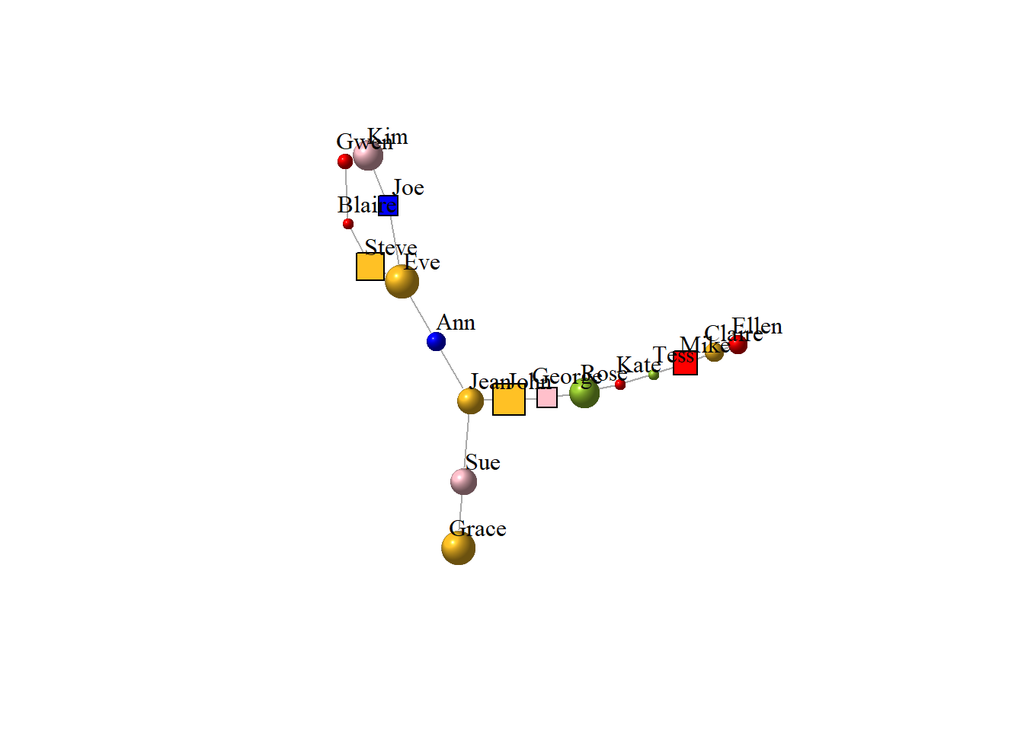

## 1.3. Create a legend for the attributes.

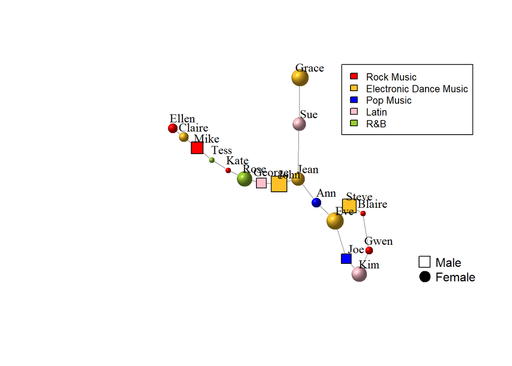

## 1.4. Add the script of how you obtained the drawings.

The code is on Rmarkdown file.

# 2. Centrality

> Next, use the dataset (friendship011.csv) to calculate the centrality of all the nodes.

## 2.1. Calculate Freeman’s closeness centrality for each node and interpret your results.

> Provide the closeness centrality score for each node.

```
## [1] "Centrality of nodes in descending order"
```

```
##      Jean      John       Ann    George       Eve      Rose       Sue      Kate
## 0.2786885 0.2698413 0.2615385 0.2537313 0.2394366 0.2328767 0.2266667 0.2098765
##     Steve       Joe     Grace      Tess    Blaire       Kim      Mike      Gwen
## 0.2048193 0.2048193 0.1868132 0.1868132 0.1789474 0.1789474 0.1650485 0.1588785
##    Claire     Ellen
## 0.1452991 0.1278195
```

Centrality measure identifies the most influential people in the network. Among the nodes, Jean is the most central node. She has the highest efficiency in spreading the information across the network.

### 2.1.1 What does it mean substantively in this case?

If we consider the flow of information, where we want to spread the information than the most efficient person to spread it would be “Jean” (information reaches all network faster) and the last efficient one would be “Ellen” (takes long for the information to reach all network). In this case, the more central a person (node) is, the closer he/she is from all other people (nodes) in the network.

### 2.1.2 Who is most closeness central?

```
## [1] "Highest centrality value: "
```

```
##      Jean
## 0.2786885
```

### 2.1.3 Provide details of the meaning of the value.

A person that has the highest number in the network means that he/she is the most influence person on this network and it is defined by the number of links that this person has.

### 2.1.4 Make sure to discuss the reference points for the closeness measure. What is the minimum and maximum value?

```
## [1] "Highest centrality: "
```

```
##      Jean
## 0.2786885
```

```
## [1] "Lowest centrality: "
```

```
##     Ellen
## 0.1278195
```

In the case where we have an information being spread by the most influencer person in the network(Jean), Ellen will be the last person (node) to receive it.

## 2.2. Calculate the betweenness centrality for each node.

### 2.2.1 What does it mean substantively in this case?

It measures the control of information that a person have in the network (bridge concept). A person that is considered the shortest path to highest number of nodes has more control of information.

### 2.2.2 Who is most betweenness central?

```
## [1] "Highest betweenness centrality: "
```

```
##      Jean
## 0.6323529
```

### 2.2.3 Provide details of the meaning of the value.

In some cases, certain parts of the network can only be reached through a certain node, that confers “power” to the node in a way that it could control the flow of information of the network.

### 2.2.4 Make sure to discuss the reference points for the betweenness measure. What is the minimum and maximum value?

```
## [1] "Maximum value:"
```

```
##      Jean
## 0.6323529
```

```
## [1] "Minimum value:"
```

```
## Grace
##     0
```

In this network, we have 3 sub-groups which are connected through Jean only. So the communication among those sub-groups is controlled by Jean(bridge). Grace and Ellen(the 2 lowest values) have least control over the information flow, since they are at the farther end of the network.

# 3. Density and reciprocity

> Figure 1 provides the advice network among 9 employees in a team.

The figure 1 was created in order to do the calculations.

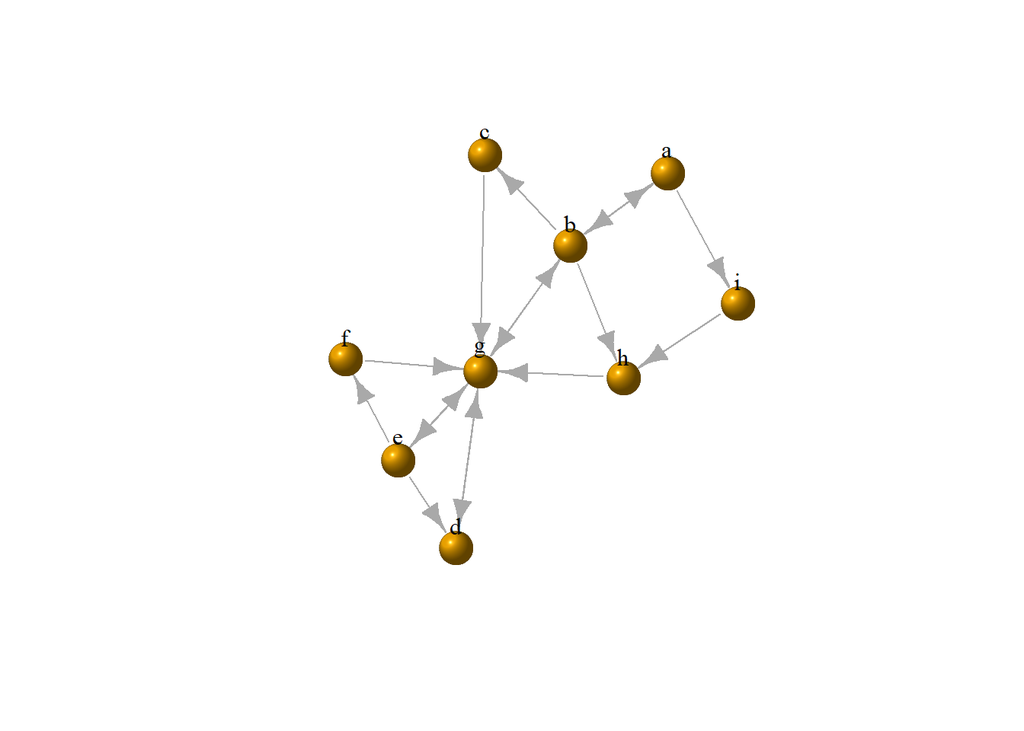

## 3.1. Calculate the density for this network and interpret.

Density = $\frac{number-of-ties}{number-of-possible-ties}$

density = $\frac{17}{9*8}$

```
## [1] "density of the network =  0.236111111111111"
```

> Make sure to show how you came to this answer.

### 3.1.1 What do you conclude substantively

> (taking into account that the network is “Who did you ask advice from in the last week?”)?

Each node in average has under than 50% of connections with each other, so their relationship might not being so strong. In a case where we want to analyze the diffusion of information, we would not have an desirable efficiency due to the lack of connections among the nodes of the network.

### 3.1.2 Make sure to discuss the reference points for the measure. What is the minimum and maximum value?

The density can vary from [0,100%], according to the number of ties of the network. In this sense, the *minimum value* would be a network that nobody is connected to anyone and the *maximum value* would be a network that everybody is connected to everybody.

# 3.2. Calculate the arc-based reciprocity index for this network and interpret.

> Make sure to show how you came to this answer.

> Arc-based Reciprocity formula: $\frac{r}{r+u}$

> ${r = }$ reciprocity connections,  
> ${u = }$ non reciprocity connections

```
## [1] "If we consider the whole network"
```

```
## [1] " reciprocity connections:  8"
```

```
## [1] " connections not reciprocity:  9"
```

```
## [1] "Arc-based Reciprocity:  0.470588235294118"
```

### 3.2.1 What do you conclude substantively?

> (taking into account that the network is “Who did you ask advice from in the last week?”)

There are more people asking advice (to receive) that than being asked (to give). In this sense “g”,“d” and “a” have the same proportion of reciprocity. However, “g” is the node that communicates more, since it receives and gives more advice than all other nodes.

### 3.2.2 Make sure to discuss the reference points for the measure. What is the minimum, expected and maximum value?

```r
arc_rec_a = arc_reci(2,1)
arc_rec_b = arc_reci(2,2)
arc_rec_c = arc_reci(0,2)
arc_rec_d = arc_reci(2,1)
arc_rec_e = arc_reci(2,2)
arc_rec_f = arc_reci(0,2)
arc_rec_h = arc_reci(0,3)
arc_rec_i = arc_reci(0,2)

paste("arc_rec_a: ",arc_rec_a)
```

```
## [1] "arc_rec_a:  0.666666666666667"
```

```r
paste("arc_rec_b: ",arc_rec_b)
```

```
## [1] "arc_rec_b:  0.5"
```

```r
paste("arc_rec_c: ",arc_rec_c)
```

```
## [1] "arc_rec_c:  0"
```

```r
paste("arc_rec_d: ",arc_rec_d)
```

```
## [1] "arc_rec_d:  0.666666666666667"
```

```r
paste("arc_rec_e: ",arc_rec_e)
```

```
## [1] "arc_rec_e:  0.5"
```

```r
paste("arc_rec_f: ",arc_rec_f)
```

```
## [1] "arc_rec_f:  0"
```

```r
paste("arc_rec_g: ",arc_rec_g)
```

```
## [1] "arc_rec_g:  0.666666666666667"
```

```r
paste("arc_rec_h: ",arc_rec_h)
```

```
## [1] "arc_rec_h:  0"
```

```r
paste("arc_rec_i: ",arc_rec_i)
```

```
## [1] "arc_rec_i:  0"
```

In this scenario we have nodes that do not reciprocate (c,f,h and i) and nodes that own the highest reciprocity (a,d,g). We can understand this network as an unbalanced network in terms of providing advice. Other interpretation is that the nodes *a*,*d* and *g*, are the ones perceived as holding the best information (advice).

# 4. Homophily/Heterophily for ego

> Make sure to show how you came to this answer.

EI-index = $\frac{(Ext - Int)}{(Ext + Int)}$

Ext = different type as node Int = Same type as node

EI-index (b) = (2 - 2)/(2 + 2)

```
## [1] 0
```

### 4.1.1 What do you conclude substantively?

> (taking into account that it is a friendship among students)

> Make sure to discuss the reference points for the measure.

EI index varies from [-1,+1] and score 0 means that an equal number of alters are of both the same “type” as the ego, and different types. Here, Person-b is a female and has 2 male friends and 2 female friends. Equally quantity of nodes types.

> Make sure to show how you came to this answer.

$Q_i = \frac{ad - bc}{ad + bc}$

a = Nodes who are the same type as ego and Directly connected to ego c = Nodes who are the same type as ego and *not* directly connected to ego

b = Nodes who are a different type than ego and directly connected to ego d = Nodes who are a different type than ego and *not* directly connected to ego

```
## [1] "Yules Q =  0"
```

### 4.2.1 What do you conclude substantively?

> (taking into account that it is a friendship among students)

> Make sure to discuss the reference points for the measure.

Yules Q varies from -1 (perfect heterophily) to +1 (perfect homophily) and a zero value would mean no pattern (i.e. equally distributed in terms of types), same as the EI index. Here, Person-b is a female and has 2 male friends and 2 female friends. Meaning, equally quantity of nodes types.

### 4.2.2 What is the difference with the EI index?

Differently from EI index, Yules Q it is *not affected* by the total number of ties or the number of the nodes in the same group, in this sense if we just multiplied our network by two, the Yules Q value would not change.